# Modelo predictivo del INPC General de México.

Soriano Urbán Jorge Stephano

09 junio 2019

### Graficando INPC General de México de 1982 a 2017.

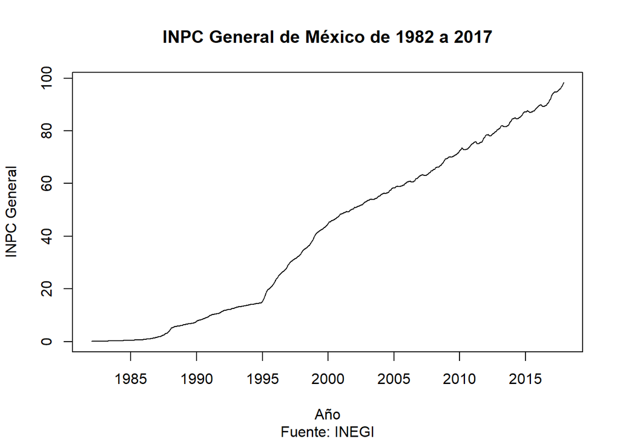

### Aplico la prueba; Augmented Dickey-Fuller (adf.test) para observar si la serie tiene el problema de raíz unitaria.

```
## Raíz unitaria (serie de tiempo no estacionaria) el valor p es:  0.2546
## Debido a que la serie no es estacionaria entonces se estabiliza la serie de tiempo
## antes de estimar el modelo.
```

#### Eliminando la tendencia y estabilizando la varianza de la serie de tiempo mediante el logaritmo diferenciado, para transformar la serie de tiempo a estacionaria.

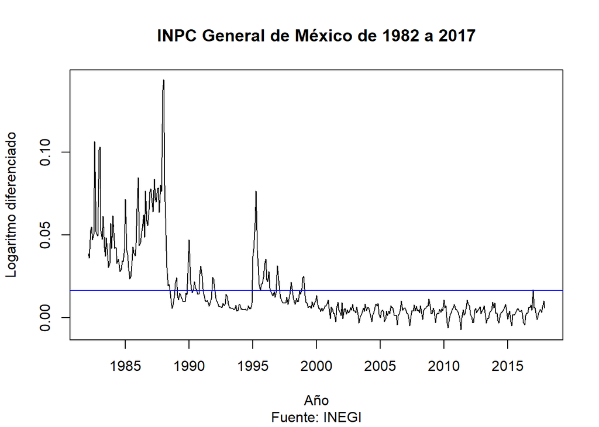

### Se vuelve a aplicar la prueba; Augmented Dickey-Fuller (adf.test) para comprobar que la serie es estacionaria

```
## Serie de tiempo estacionaria el valor p es:  0.01
## por lo tanto, se rechaza la H0 de no estacionariedad.
## Se puede entonces calcular el modelo de ajuste
```

#### Eliminando el componente estacional de la serie de tiempo mediante el cálculo de las diferencias de orden 12

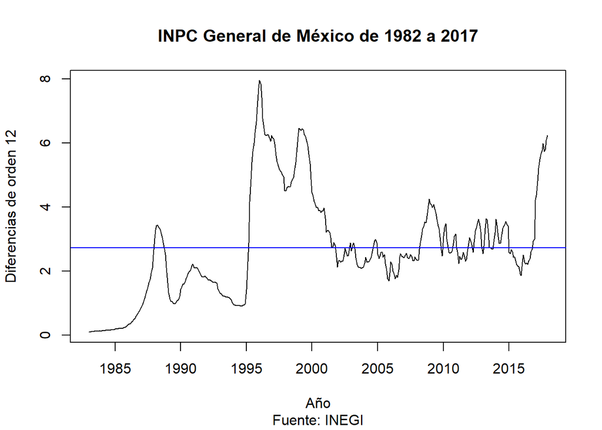

### Gráficas de la función de autocorrelación (ACF) y de la función de autocorrelación parcial (PACF) para obtener los patrones del proceso AR() y MA().

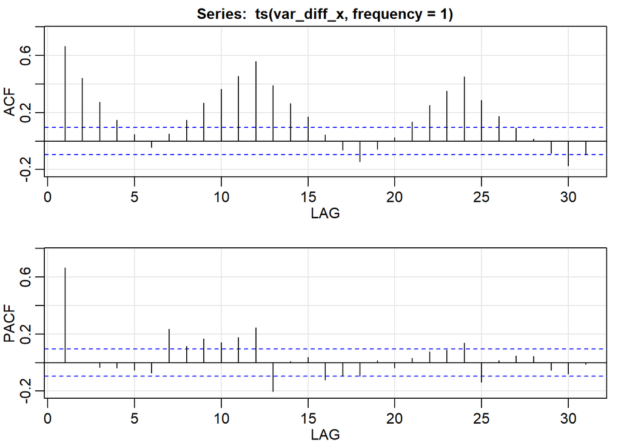

```
##         ACF  PACF
##  [1,]  0.66  0.66
##  [2,]  0.44  0.00
##  [3,]  0.27 -0.03
##  [4,]  0.15 -0.04
##  [5,]  0.05 -0.05
##  [6,] -0.04 -0.07
##  [7,]  0.05  0.24
##  [8,]  0.15  0.12
##  [9,]  0.27  0.17
## [10,]  0.36  0.14
## [11,]  0.46  0.18
## [12,]  0.56  0.24
## [13,]  0.39 -0.20
## [14,]  0.26  0.01
```

[output cut: 17 more lines]

### Gráficas de la función de autocorrelación (ACF) y de la función de autocorrelación parcial (PACF) para obtener los patrones del proceso AR() y MA() del componente estacional.

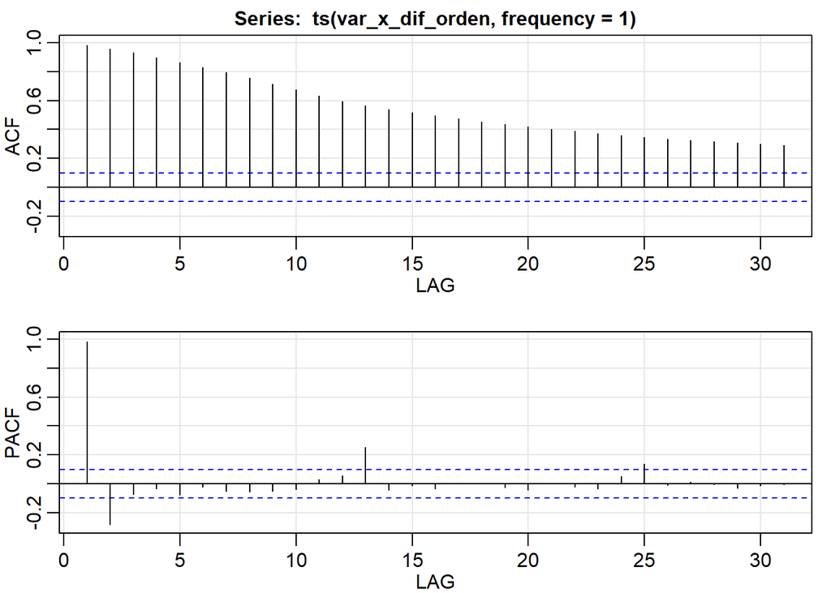

```
##        ACF  PACF
##  [1,] 0.98  0.98
##  [2,] 0.96 -0.28
##  [3,] 0.93 -0.07
##  [4,] 0.90 -0.03
##  [5,] 0.87 -0.08
##  [6,] 0.83 -0.02
##  [7,] 0.79 -0.05
##  [8,] 0.76 -0.06
##  [9,] 0.72 -0.05
## [10,] 0.67 -0.04
## [11,] 0.63  0.03
## [12,] 0.60  0.06
## [13,] 0.57  0.25
## [14,] 0.54 -0.04
```

[output cut: 17 more lines]

### Generando modelos de ajuste

#### Criterios AIC y BIC de los modelos de ajuste

```
##      Patrones_pdq_y_PDQ AIC                 BIC
## [1,] "(0,2,0) (2,0,0)"  "-293.417135435434" "-281.225779809371"
## [2,] "(0,2,1) (2,0,0)"  "-325.312683983515" "-309.057543148765"
## [3,] "(1,2,0) (2,0,0)"  "-312.927112381991" "-296.671971547241"
## [4,] "(1,2,1) (2,0,0)"  "-380.324908733515" "-360.005982690077"
## [5,] "(3,2,3) (2,0,0)"  "-379.133467334704" "-342.559400456516"
## [6,] "(6,2,6) (2,0,0)"  "-383.349884695292" "-322.393106564978"
```

```
## Modelo de ajuste con valor Akaike más bajo: 6
```

```
## Valor Akaike: -383
```

```
## Modelo de ajuste con valor BIC más bajo: 4
```

```
## Valor BIC: -360
```

#### Sesgo y Curtosis de los modelos de ajuste

```
##      Sesgo Curtosis
## [1,]  0.27       16
## [2,]  0.93       13
## [3,]  0.70       13
## [4,]  1.67       18
## [5,]  1.56       17
## [6,]  1.71       18
```

#### Medidads de precisión de los modelos de ajuste

```
##      MAPE      ME RMSE   MAE   MPE MASE
## [1,] 0.44 0.00073 0.17 0.100 0.042 0.39
## [2,] 0.46 0.00134 0.16 0.102 0.063 0.40
## [3,] 0.45 0.00103 0.17 0.102 0.050 0.40
## [4,] 0.48 0.00857 0.15 0.091 0.225 0.36
## [5,] 0.49 0.00860 0.15 0.091 0.224 0.36
## [6,] 0.48 0.00897 0.15 0.089 0.219 0.35
```

```
## Modelo de ajuste con MAPE más bajo: 1
```

```
## Valor MAPE: 0.44
```

```
## Modelo de ajuste con ME más bajo: 1
```

```
## Valor ME: 0.00073
```

```
## Modelo de ajuste con RMSE más bajo: 6
```

```
## Valor RMSE: 0.15
```

```
## Modelo de ajuste con MAE más bajo: 6
```

```
## Valor MAE: 0.089
```

```
## Modelo de ajuste con MPE más bajo: 1
```

```
## Valor MPE: 0.042
```

```
## Modelo de ajuste con MASE más bajo: 6
```

```
## Valor MASE: 0.35
```

### Del análisis de los modelos de ajuste y de los estadísticos de precisión junto con el análisis de las funciones de autocorrelación obtengo dos modelos de ajuste;

### Modelo I

#### El primer modelo contiene el siguiente patrón **AR(1)I(2)MA(1)** junto con el patrón de residuos (P,D,Q): **AR(2)I(0)MA(0)**. Se deduce el siguiente modelo de ajuste:

###### **ajusteARIMA <- arima(INPC_General, order=c(1,2,1), seasonal = list(order = c(2,0,0), period = 12), method=“ML”, include.mean = TRUE)**

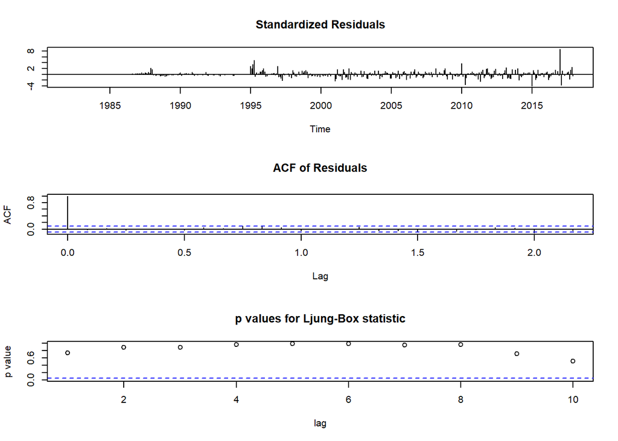

#### Observando los p valores del estadístico Ljung-Box se identifica que los residuos del modelo ajustado están por encima de 0.05 (línea punteada azul), por lo tanto, los datos de la serie de tiempo no están autocorrelacionados. De lo contrario la exactitud del modelo predictivo se reduce y la interpretación de los datos será errónea.

### Graficando los cuantiles de la distribución normal de los residuos del modelo ajustado.

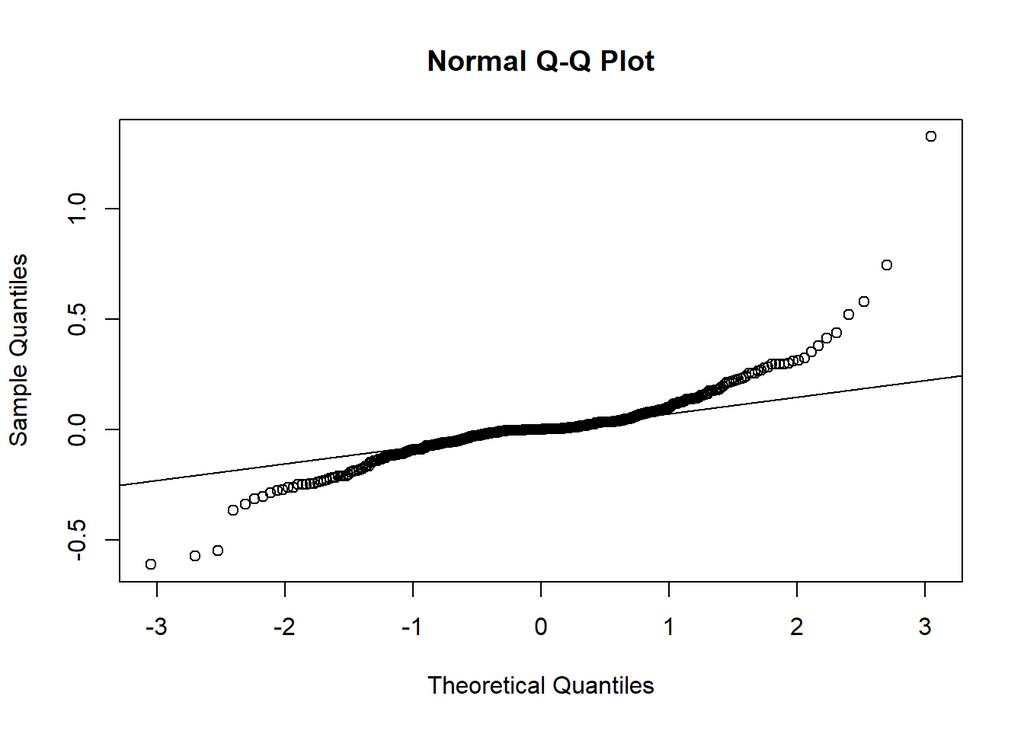

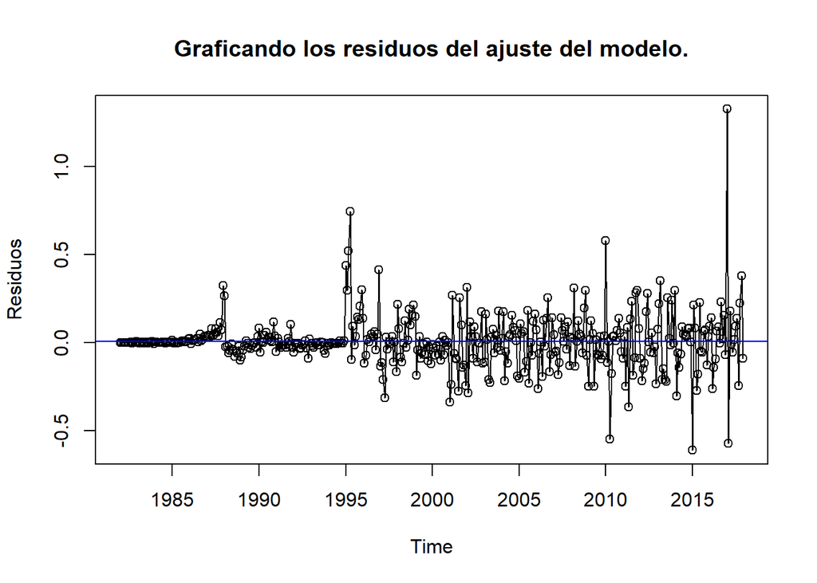

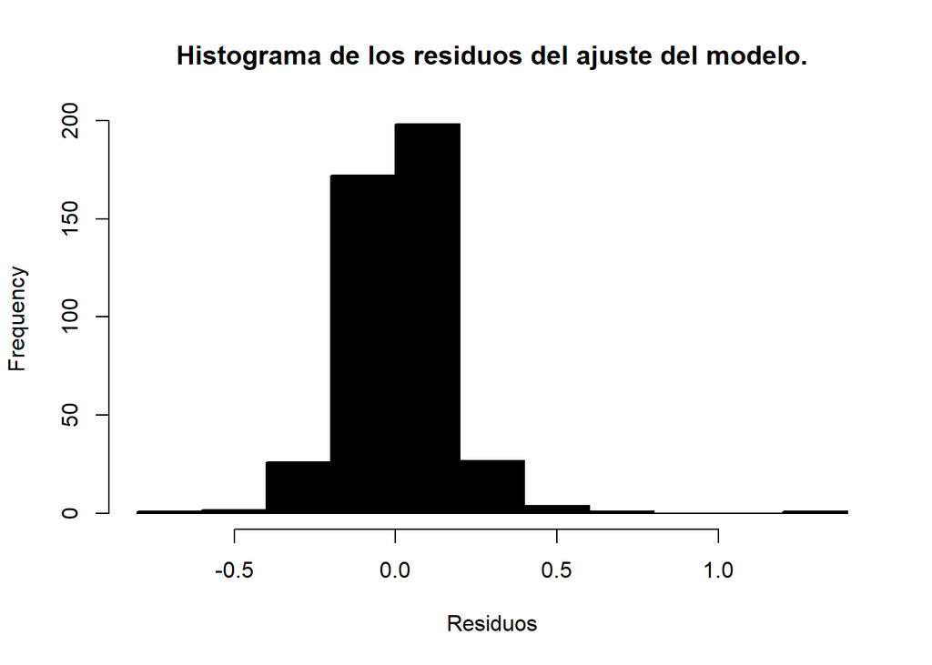

#### Resumen estadístico del ajuste del modelo

```
## Sigma Cuadrado: 0.023
```

```
## Media de los residuos: 0.0086
```

```
## Akaike: -380
```

```
## Skewness: 1.7
```

```
## Kurtosis: 18
```

### Simulación de pronóstico: INPC General.

##### Línea **roja** valores observados de la serie de tiempo

##### Línea **azul** valores pronosticados de la serie de tiempo

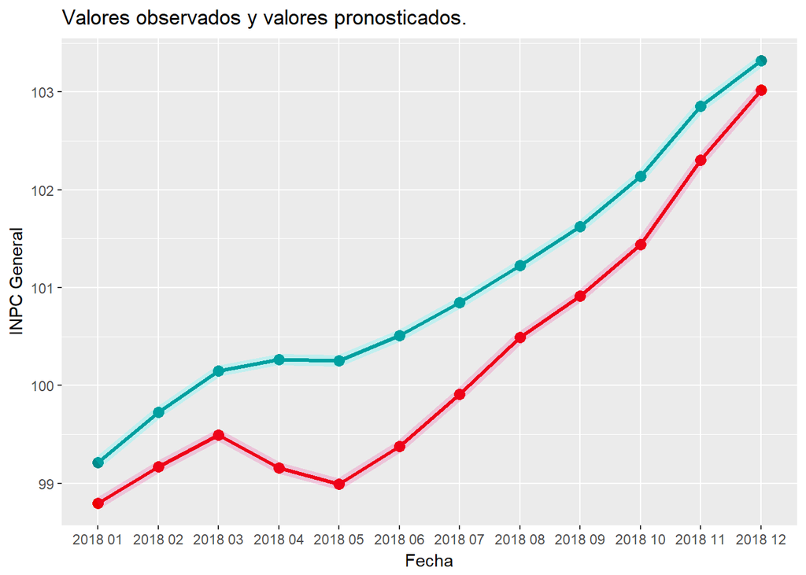

### **Pronóstico de 12 meses de INPC General de México.**

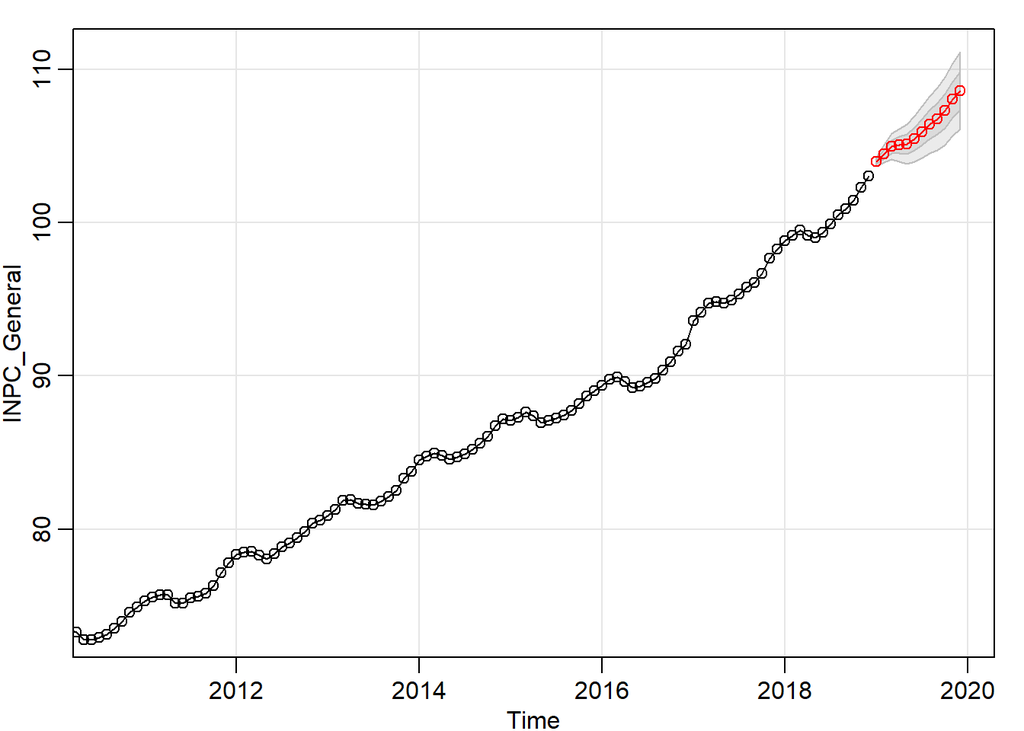

### Valores de la predicción

```
##      Jan Feb Mar Apr May Jun Jul Aug Sep Oct Nov Dec
## 2019 104 104 105 105 105 105 106 106 107 107 108 109
```

### El segundo modelo contiene el siguiente patrón **AR(6)I(2)MA(6)** junto con el patrón de residuos (P,D,Q): **AR(2)I(0)MA(0)** . Se deduce el siguiente modelo de ajuste:

###### **ajusteARIMA <- arima(INPC_General, order=c(6,2,6), seasonal = list(order = c(2,0,0), period = 12), method=“ML”, include.mean = TRUE)**

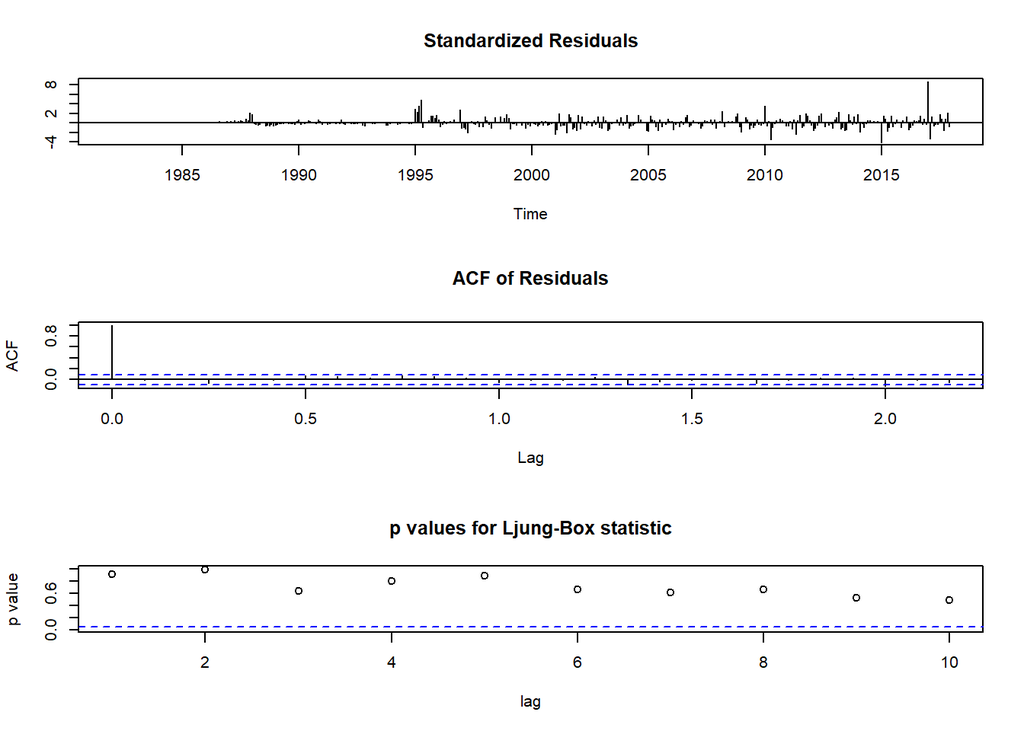

#### Observando los p valores del estadístico Ljung-Box se identifica que los residuos del modelo ajustado están por encima de 0.05 (línea punteada azul), por lo tanto, los datos de la serie de tiempo no están autocorrelacionados. De lo contrario la exactitud del modelo predictivo se reduce y la interpretación de los datos será errónea.

### Graficando los cuantiles de la distribución normal de los residuos del modelo ajustado.

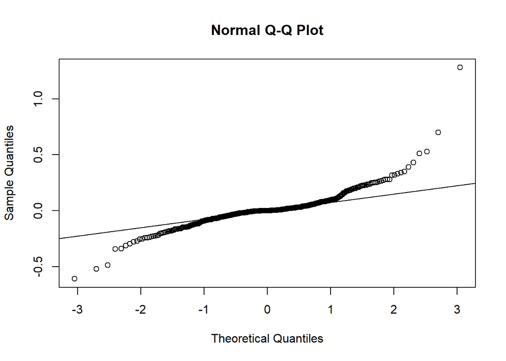

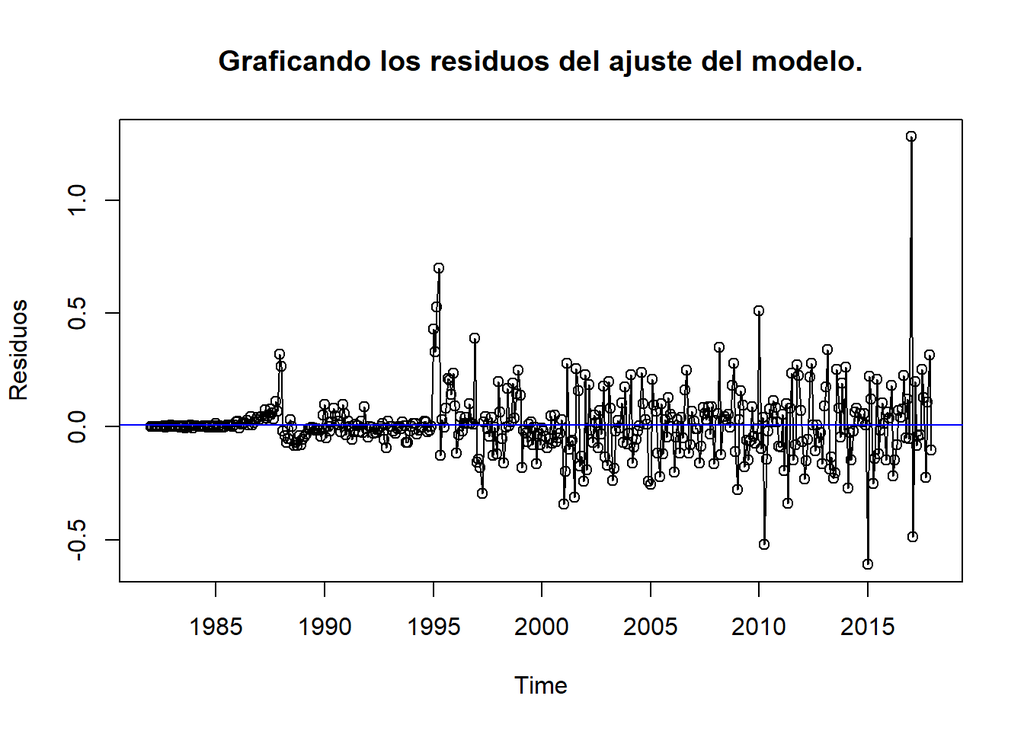

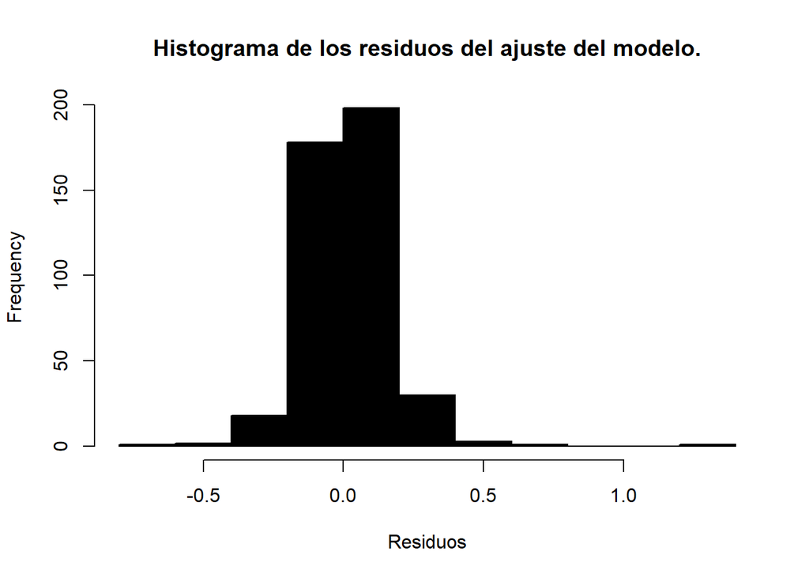

#### Resumen estadístico del ajuste del modelo

```
## Sigma Cuadrado: 0.022
```

```
## Media de los residuos: 0.009
```

```
## Akaike: -383
```

```
## Skewness: 1.7
```

```
## Kurtosis: 18
```

### Simulación de pronóstico: INPC General.

##### Línea **roja** valores observados de la serie de tiempo

##### Línea **azul** valores pronosticados de la serie de tiempo

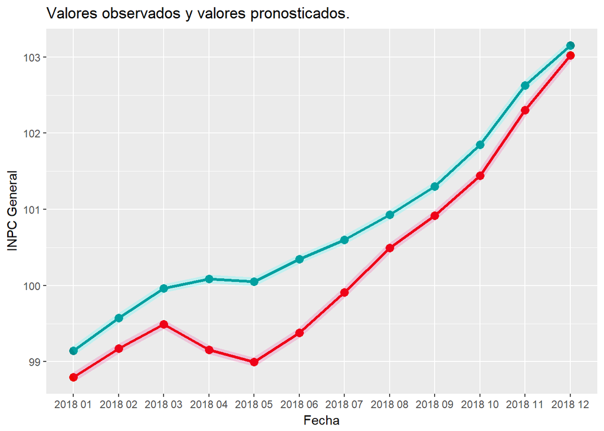

### **Pronóstico de 12 meses de INPC General de México.**

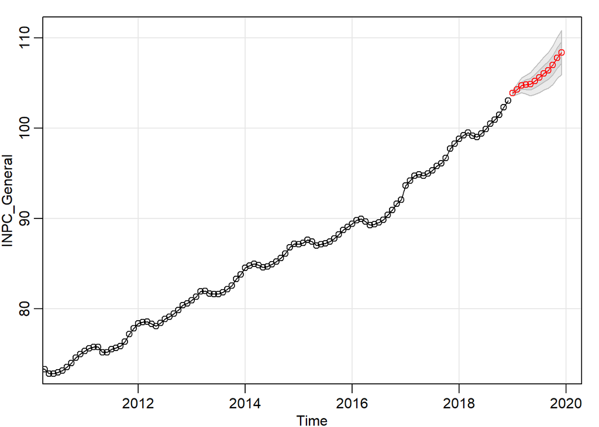

### Valores de la predicción

```
##      Jan Feb Mar Apr May Jun Jul Aug Sep Oct Nov Dec
## 2019 104 104 105 105 105 105 106 106 106 107 108 108
```